# Data Science Capstone -Ngram Prediction

Edric Kaw

6/27/2020

# Objectives

The objective is to create an [application](https://edrickaw.shinyapps.io/ShinyNgram/) that can be used to predict next word based on your input.

# Algorithms

1. N-Gram model being adopted to predict next word based on user’s input.
2. Based on input words, algorithm searches through the corpora for most frequent combinations of words based on samples from three data sources: blogs, twitter and news.
3. For the prediction, based on the most frequent combinations of words (highest probablity) will be output as the predicted words.
4. There is a slider in the apps which will output the highest to lowest probability of combinations of words based on users to get the number of predicted words.

# R codes and Shiny Apps

For more details on R codes please visit: https://github.com/EdricKaw/DataScienceCapstone

For the user interface application please visit: https://edrickaw.shinyapps.io/ShinyNgram/

# Usage of Application

The **picture** below shows the user interface for the [application](https://edrickaw.shinyapps.io/ShinyNgram/) whereby user can enter input in the text box and can get numbers of predicted word through the slider. There are three tabs to show the prediction words through:

- **Main** (List of prediction words)
- **Table output** (Table output of prediction words)
- **Word cloud** (Word cloud of prediction words)

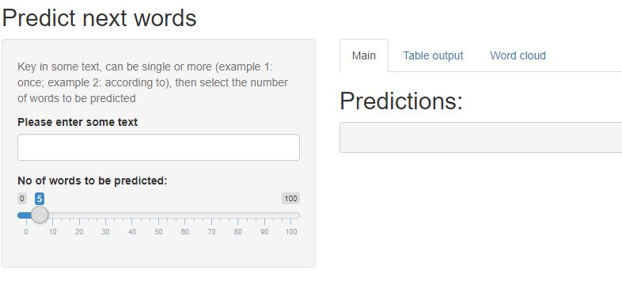